# Course Project 1

Diego Gajardo

19 de mayo de 2016

### Loading and preprocesing the data

We read the data and remove the NAs cases:

```r
rawdata <- read.csv("activity.csv")
ok <- complete.cases(rawdata)
cleandata <- rawdata[ok,]
cleandata$date <- factor(cleandata$date)
```

Then we take “interval” variable as factor to make future calculations:

```r
rawdata$interval <- as.factor(rawdata$interval)
cleandata$interval <- as.factor(cleandata$interval)
```

### What is mean total number of steps taken per day?

The total number of steps taken per day is given by:

```r
total_steps <- tapply(cleandata$steps,cleandata$date,sum)
(total_steps)
```

```
## 2012-10-02 2012-10-03 2012-10-04 2012-10-05 2012-10-06 2012-10-07
##        126      11352      12116      13294      15420      11015
## 2012-10-09 2012-10-10 2012-10-11 2012-10-12 2012-10-13 2012-10-14
##      12811       9900      10304      17382      12426      15098
## 2012-10-15 2012-10-16 2012-10-17 2012-10-18 2012-10-19 2012-10-20
##      10139      15084      13452      10056      11829      10395
## 2012-10-21 2012-10-22 2012-10-23 2012-10-24 2012-10-25 2012-10-26
##       8821      13460       8918       8355       2492       6778
## 2012-10-27 2012-10-28 2012-10-29 2012-10-30 2012-10-31 2012-11-02
##      10119      11458       5018       9819      15414      10600
## 2012-11-03 2012-11-05 2012-11-06 2012-11-07 2012-11-08 2012-11-11
##      10571      10439       8334      12883       3219      12608
## 2012-11-12 2012-11-13 2012-11-15 2012-11-16 2012-11-17 2012-11-18
##      10765       7336         41       5441      14339      15110
## 2012-11-19 2012-11-20 2012-11-21 2012-11-22 2012-11-23 2012-11-24
##       8841       4472      12787      20427      21194      14478
## 2012-11-25 2012-11-26 2012-11-27 2012-11-28 2012-11-29
##      11834      11162      13646      10183       7047
```

Now we make a histogram of the total steps:

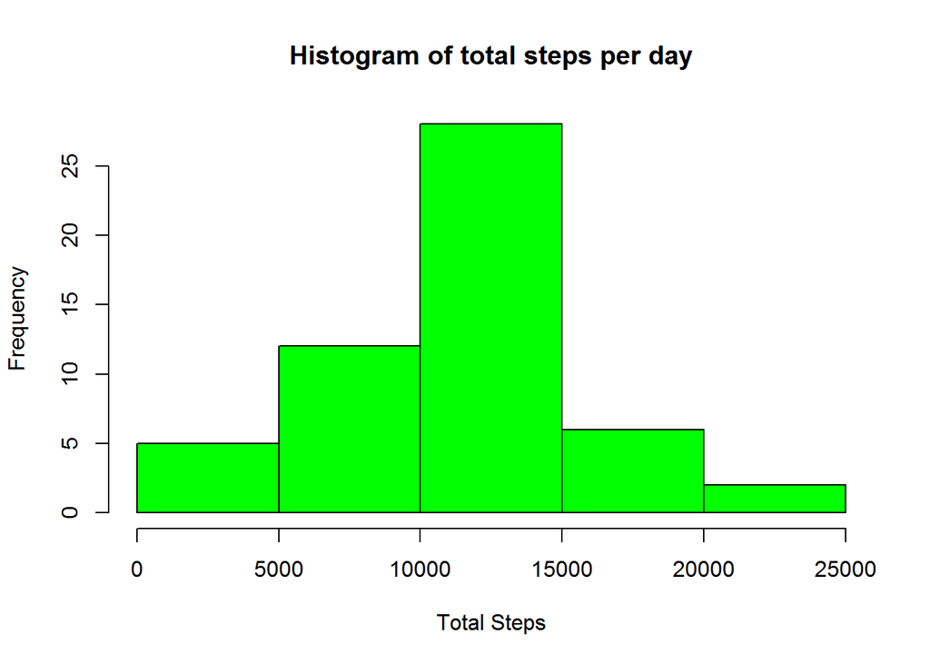

```r
hist(total_steps, col = "green", xlab = "Total Steps", main = "Histogram of total steps per day")
```

Finally, we take the *mean* and *median* of the total number of steps:

```r
total_mean <- mean(total_steps)
total_median <- median(total_steps)
total_mean
```

```
## [1] 10766.19
```

```r
total_median
```

```
## [1] 10765
```

### What is the average daily activity pattern?

First we take the average number of steps on each interval, and then we plot:

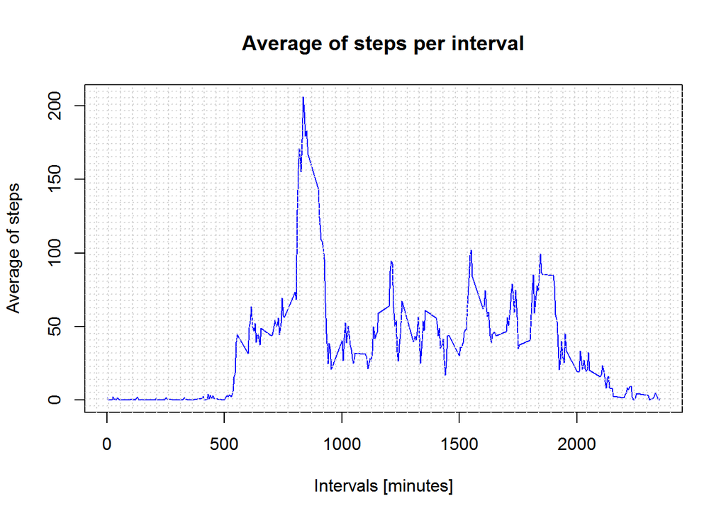

```r
avg <- tapply(cleandata$steps, cleandata$interval, mean)
plot(avg ~ levels(cleandata$interval), type = "l", col = "blue", xlab ="Intervals [minutes]", ylab = "Average of steps", main = "Average of steps per interval")
grid(nx = 50)
```

And the interval with the maximum number of steps:

```r
avg[avg == max(avg)]
```

```
##      835
## 206.1698
```

### Imputing missing values

First we calculate the number of missing values:

```r
total_nas <- sum(!complete.cases(rawdata))
total_nas
```

```
## [1] 2304
```

Now we fill the misses values with the mean of the interval, and build a new dataset:

```r
na_cases <- which(!complete.cases(rawdata))
filldata <- rawdata
for (i in na_cases) {
        interval <- as.character(filldata[i,3])
        filldata[i,1] <- avg[interval]
}
head(filldata)
```

```
##       steps       date interval
## 1 1.7169811 2012-10-01        0
## 2 0.3396226 2012-10-01        5
## 3 0.1320755 2012-10-01       10
## 4 0.1509434 2012-10-01       15
## 5 0.0754717 2012-10-01       20
## 6 2.0943396 2012-10-01       25
```

And we have a new dataset called *filldata* Finally, we make an histogram of the total steps per day:

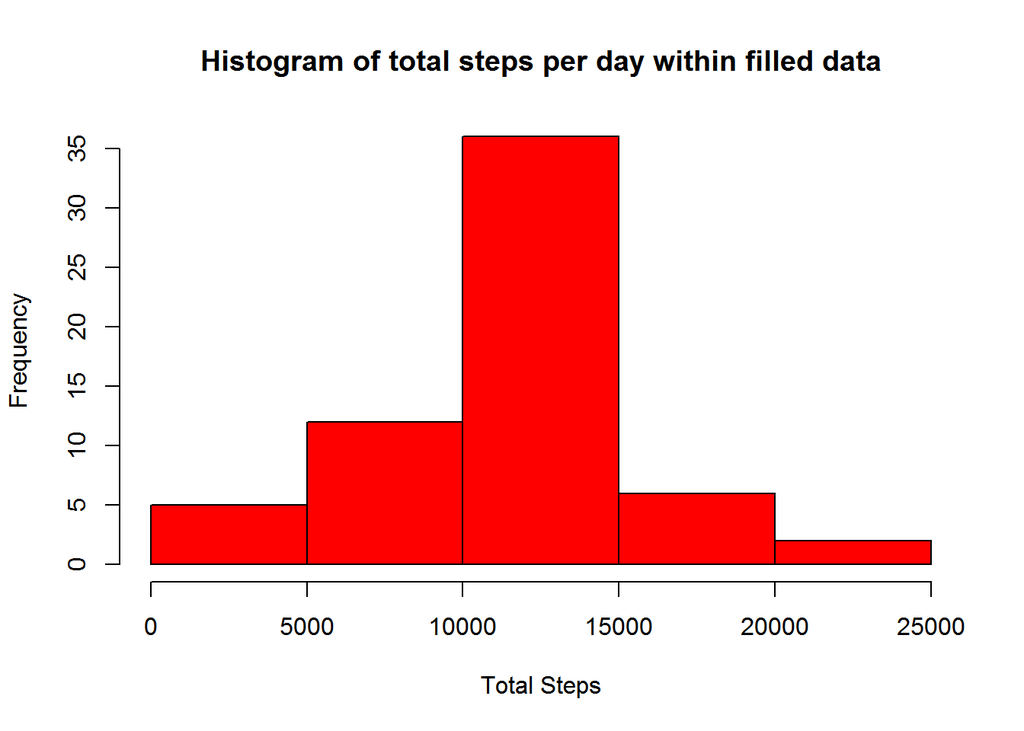

```r
total_steps_fill <- tapply(filldata$steps,filldata$date,sum)
hist(total_steps_fill, col = "red", xlab = "Total Steps", main = "Histogram of total steps per day within filled data")
```

And calculate mean and median for the new data:

```r
total_mean_fill <- mean(total_steps_fill)
total_median_fill <- median(total_steps_fill)
total_mean_fill
```

```
## [1] 10766.19
```

```r
total_median_fill
```

```
## [1] 10766.19
```

It’s easy to note that there is a little difference between the old and new median. The efect of filling the missing values is minimun, that is because we are using the average values to do it.

### Are there differences in activity patterns between weekdays and weekends?

First we create the new factor variable:

```r
filldata["day"] <- NA
for (i in seq(1,nrow(filldata))){
        filldata[i,"day"] <- ifelse(weekdays(as.Date(filldata[i,"date"])) == "sábado" | weekdays(as.Date(filldata[i,"date"])) == "domingo", "weekend","weekday")
}
filldata$day <- as.factor(filldata$day)
head(filldata)
```

```
##       steps       date interval     day
## 1 1.7169811 2012-10-01        0 weekday
## 2 0.3396226 2012-10-01        5 weekday
## 3 0.1320755 2012-10-01       10 weekday
## 4 0.1509434 2012-10-01       15 weekday
## 5 0.0754717 2012-10-01       20 weekday
## 6 2.0943396 2012-10-01       25 weekday
```

And now we plot the average number of steps taken:

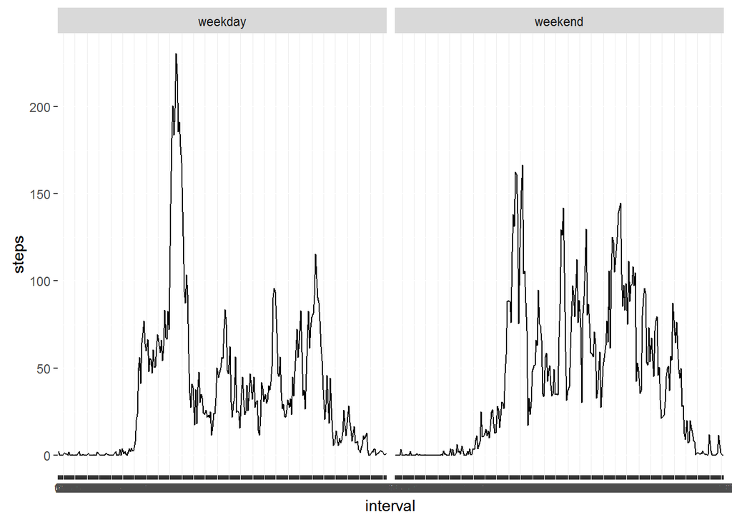

```r
library(ggplot2)
ggplot(filldata, aes(x = interval, y = steps, group = 1)) + stat_summary(fun.y = "mean", geom = "line") + facet_wrap(~day)
```